# COMPSCIX 415.2 Homework 6

# 4 Analysis of The Gamma Distribution

The Central Limit Theorem states that the sampling distribution of sample means is approximately Normal, regardless of the distribution of your population. For this exercise our population distribution will be a Gamma(1,2) distribution, and we’ll show that the sampling distribution of the mean is in fact normally distributed.

1. Generate a random sample of size n = 10000 from a gamma(1,2) distribution and plot a histogram or density curve. Use the code below to help you get your sample.

```r
n <- 10000
# look at ?rgamma to read about this function
gamma_samp <- tibble(x = rgamma(n, shape = 1, scale = 2))
```

**Answer**

Let’s plot the graph.

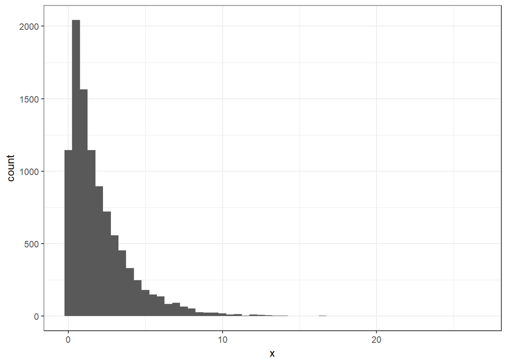

```r
n <- 10000
# look at ?rgamma to read about this function
gamma_samp <- tibble(x = rgamma(n, shape = 1, scale = 2))

# Histogram
ggplot(data=gamma_samp) +
  geom_histogram(aes(x = x), binwidth = 0.5) +
  theme_bw()
```

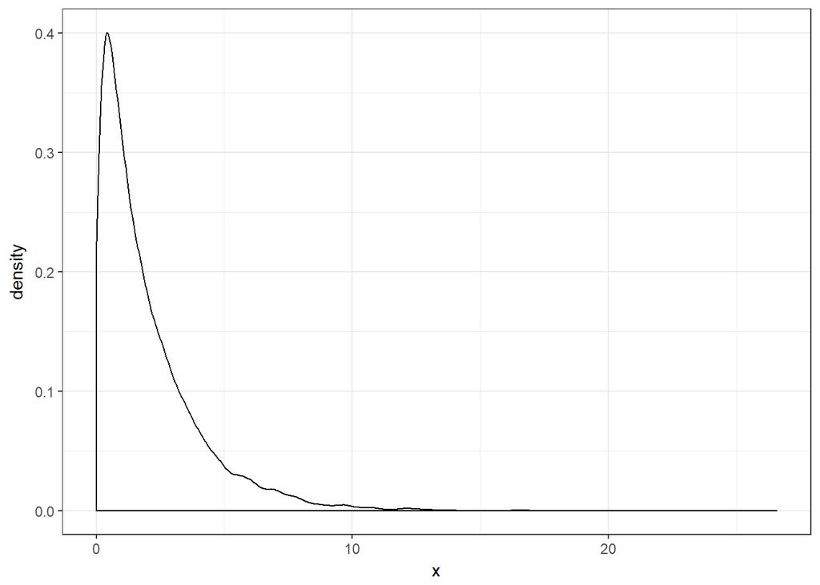

```r
# Density curve
ggplot(data=gamma_samp) +
  geom_density(aes(x = x)) +
  theme_bw()
```

2. What is the mean and standard deviation of your sample? They should both be close to 2 because for a gamma distribution: mean = shape x scale variance = shape x scaleˆ2

```r
mean_samp <- gamma_samp %>% .[['x']] %>% mean()
```

**Answer**

```r
n <- 10000
gamma_samp <- tibble(x = rgamma(n, shape = 1, scale = 2))

mean_samp <- gamma_samp %>% .[['x']] %>% mean()
mean_samp
```

```
## [1] 2.032275
```

```r
sd_samp <- gamma_samp %>% .[['x']] %>% sd()
sd_samp
```

```
## [1] 2.015978
```

True, both mean and standard deviation are close to 2.

3. Pretend the distribution of our population of data looks like the plot above. Now take a sample of size n = 30 from a Gamma(1,2) distribution, plot the histogram or density curve, and calculate the mean and standard deviation.

**Answer**

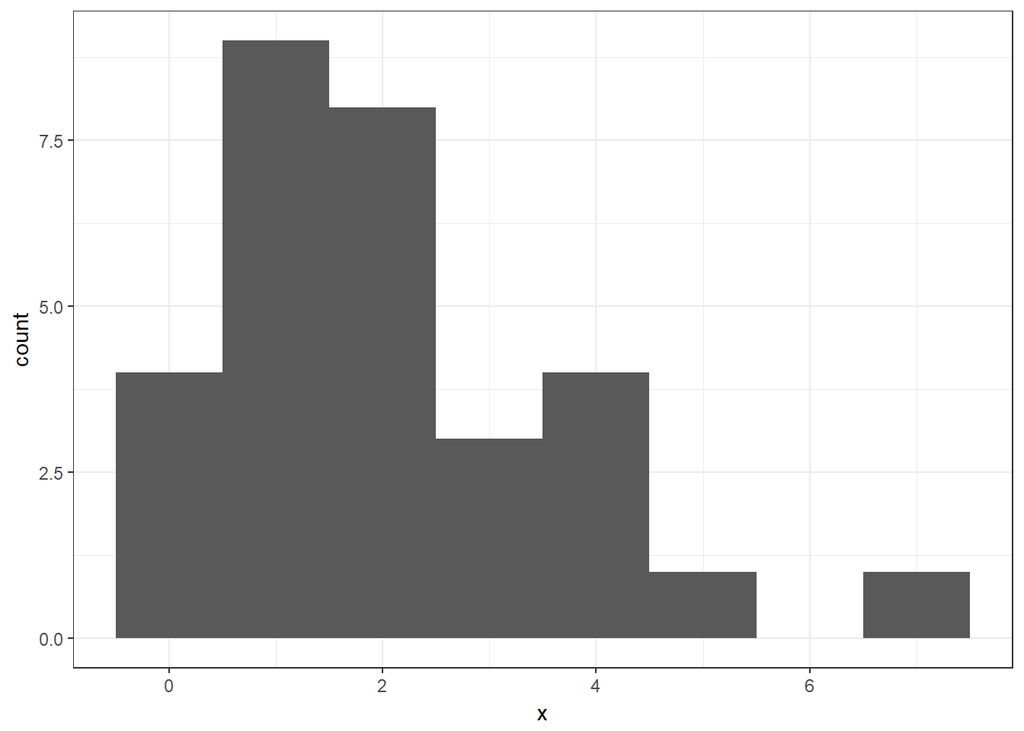

```r
n <- 30
gamma_samp <- tibble(x = rgamma(n, shape = 1, scale = 2))

ggplot(data=gamma_samp) +
  geom_histogram(aes(x = x), binwidth = 1) +
  theme_bw()
```

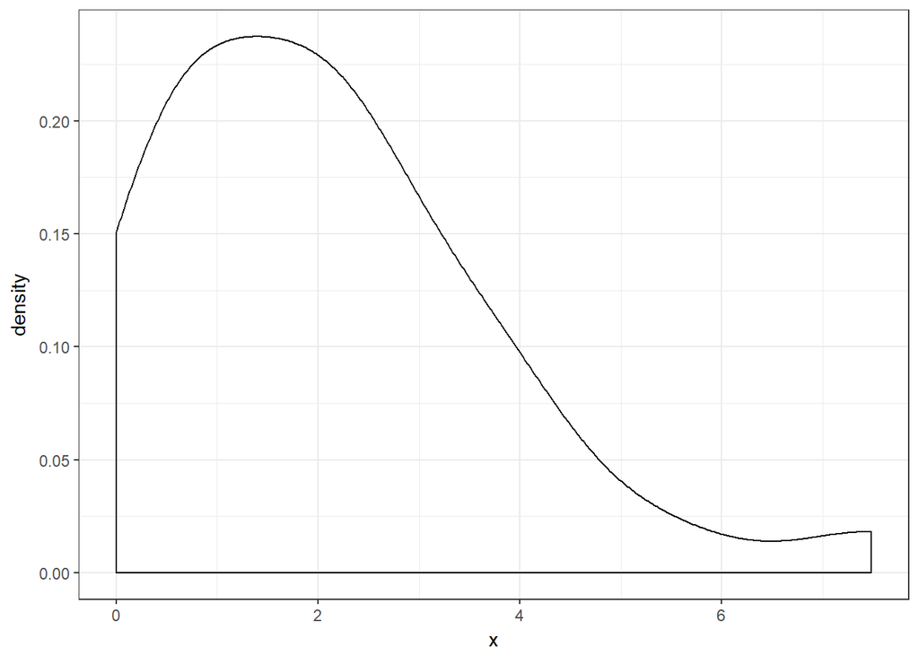

```r
ggplot(data=gamma_samp) +
  geom_density(aes(x = x)) +
  theme_bw()
```

```r
mean_samp <- gamma_samp %>% .[['x']] %>% mean()
mean_samp
```

```
## [1] 2.098363
```

```r
sd_samp <- gamma_samp %>% .[['x']] %>% sd()
sd_samp
```

```
## [1] 1.697065
```

4. Take a sample of size n = 30, again from the Gamma(1,2) distribution, calculate the mean, and assign it to a vector named mean_samp. Repeat this 10000 times!!!! The code below might help.

```r
# create a vector with 10000 NAs
mean_samp <- rep(NA, 10000)

# start a loop
for(i in 1:10000) {
g_samp <- rgamma(30, shape = 1, scale = 2)
mean_samp[i] <- mean(g_samp)
}

#Convert vector to a tibble
mean_samp <- tibble(mean_samp)
```

**Answer**

Let’s execute the code.

```r
# create a vector with 10000 NAs
mean_samp <- rep(NA, 10000)

# start a loop
for(i in 1:10000) {
g_samp <- rgamma(30, shape = 1, scale = 2)
mean_samp[i] <- mean(g_samp)
}

#Convert vector to a tibble
mean_samp <- tibble(mean_samp)

mean_samp
```

```
## # A tibble: 10,000 x 1
##    mean_samp
##        <dbl>
##  1      2.05
##  2      1.70
##  3      2.10
##  4      1.60
##  5      1.56
##  6      2.08
##  7      2.60
##  8      2.22
##  9      2.08
## 10      1.81
## # ... with 9,990 more rows
```

5. Make a histogram of your collection of means from above (mean_samp).

**Answer**

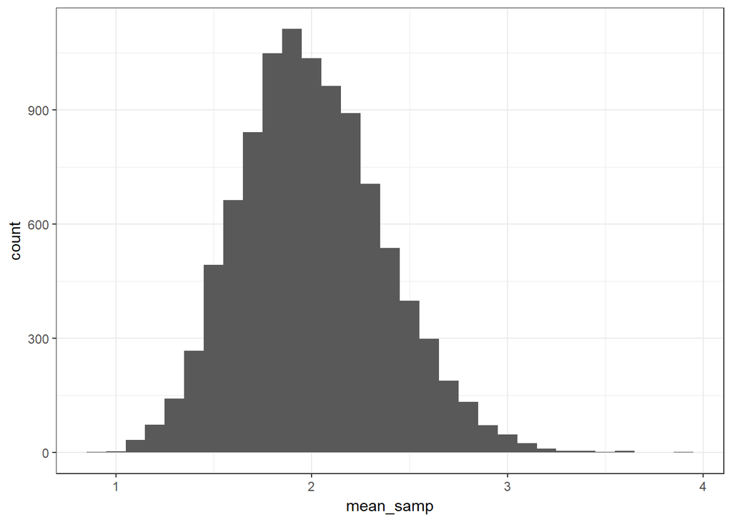

```r
# create a vector with 10000 NAs
mean_samp <- rep(NA, 10000)

# start a loop
for(i in 1:10000) {
g_samp <- rgamma(30, shape = 1, scale = 2)
mean_samp[i] <- mean(g_samp)
}

#Convert vector to a tibble
mean_samp <- tibble(mean_samp)

ggplot(data=mean_samp) +
  geom_histogram(aes(x = mean_samp), binwidth = 0.1) +
  theme_bw()
```

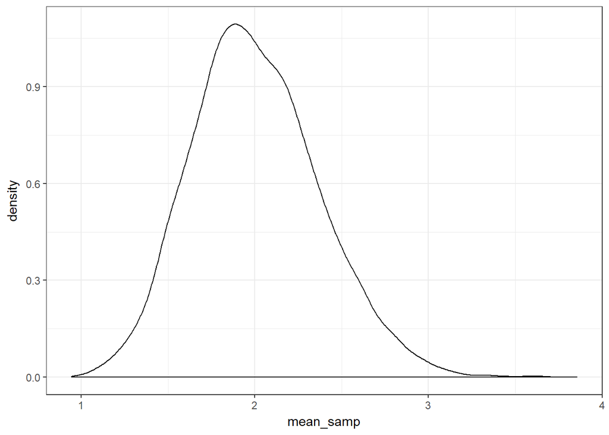

```r
ggplot(data=mean_samp) +
  geom_density(aes(x = mean_samp)) +
  theme_bw()
```

6. Calculate the mean and standard deviation of all of your sample means.

**Answer**

```r
# create a vector with 10000 NAs
mean_samp <- rep(NA, 10000)

# start a loop
for(i in 1:10000) {
g_samp <- rgamma(30, shape = 1, scale = 2)
mean_samp[i] <- mean(g_samp)
}

mean_of_mean_samp <- mean(mean_samp)
mean_of_mean_samp
```

```
## [1] 1.997411
```

```r
sd_of_mean_samp <- sd(mean_samp)
sd_of_mean_samp
```

```
## [1] 0.3651051
```

7. Did anything surprise you about your answers to #6?

**Answer**

Yes, when we took a 10000 mean and calculated mean and standard deviation, mean remain same (~2) but standard deviation decreases (makes sense).

8. According to the Central Limit Theorem, the mean of your sampling distribution should be very close to 2, and the standard deviation of your sampling distribution should be close to 0.365. Repeat #4-#6, but now with a sample of size n = 300 instead. Do your results match up well with the theorem?

**Answer**

Let’s find the mean and standard deviation for n=300

```r
# create a vector with 10000 NAs
mean_samp <- rep(NA, 10000)

# start a loop
for(i in 1:10000) {
g_samp <- rgamma(300, shape = 1, scale = 2)
mean_samp[i] <- mean(g_samp)
}

mean_of_mean_samp <- mean(mean_samp)
mean_of_mean_samp
```

```
## [1] 1.998024
```

```r
sd_of_mean_samp <- sd(mean_samp)
sd_of_mean_samp
```

```
## [1] 0.1162154
```

I see the mean remains same ~2 but the statndard deviation is decreasing. Let me take sample size n=3000.

n=3000

```r
# create a vector with 10000 NAs
mean_samp <- rep(NA, 10000)

# start a loop
for(i in 1:10000) {
g_samp <- rgamma(3000, shape = 1, scale = 2)
mean_samp[i] <- mean(g_samp)
}

mean_of_mean_samp <- mean(mean_samp)
mean_of_mean_samp
```

```
## [1] 1.999649
```

```r
sd_of_mean_samp <- sd(mean_samp)
sd_of_mean_samp
```

```
## [1] 0.0365429
```

We see standard deviation decreases.

———————————————————————————————————

**End of Homework 6**